# UNICEF Report – Youth HIV Knowledge Around the World

Author

Saniya Mansuri

Published

April 27, 2025

# Introduction

Young people are at the heart of the global fight against HIV. Ensuring that adolescents and youth have comprehensive, correct knowledge about HIV prevention is critical to ending the epidemic. This report explores global trends in youth HIV knowledge, highlighting progress made and the gaps that still remain.

Comprehensive HIV education empowers young people to make safe choices. Higher levels of knowledge are linked to lower infection rates.

```python
# Install required packages (hide output)
!pip install polars plotnine geopandas > /dev/null 2>&1

# Import libraries
import polars as pl
import pandas as pd
from plotnine import *
import geopandas as gpd
import matplotlib.pyplot as plt

# Upload the indicator file (hide output)
from google.colab import files
_ = files.upload()

# Load the indicator dataset
indicator = pl.read_csv(
    "unicef_indicator_1.csv",
    schema_overrides={"time_period": pl.Utf8}
)
```

```python
# Lowercase indicators
indicator = indicator.with_columns(
    pl.col("indicator").str.to_lowercase()
)

# Fix time_period safely
indicator = indicator.with_columns(
    pl.col("time_period").str.slice(0, 4).alias("time_period")
)
indicator = indicator.with_columns(
    pl.col("time_period").cast(pl.Int32)
)

# Now filter for HIV knowledge
data_hiv = (indicator
    .filter(pl.col("indicator").str.contains("hiv"))
    .filter(pl.col("time_period") >= 2000)
    .filter(pl.col("obs_value").is_not_null())
    .filter(pl.col("obs_value") > 0)
)
```

# Latest HIV knowledge globally

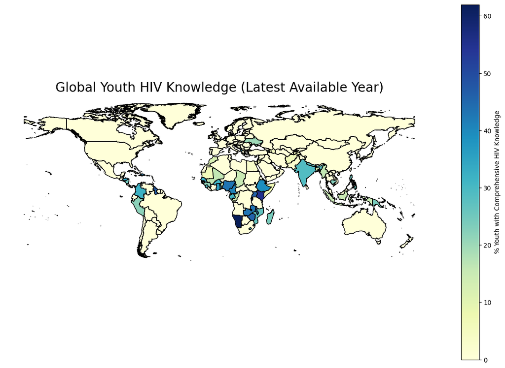

```python
shape_world = gpd.read_file("https://public.opendatasoft.com/api/explore/v2.1/catalog/datasets/world-administrative-boundaries/exports/shp")

hiv_latest = (data_hiv
    .sort(["country", "time_period"], descending=[False, True])
    .group_by("country")
    .agg(pl.col("obs_value").first().alias("latest_obs_value"))
)

map_data = shape_world.merge(hiv_latest.to_pandas(), left_on="name", right_on="country", how="left")

map_data['latest_obs_value'] = pd.to_numeric(map_data['latest_obs_value'], errors='coerce').fillna(0)

fig, ax = plt.subplots(1, 1, figsize=(15, 10))
shape_world.boundary.plot(ax=ax, linewidth=1, color="black")
map_data.plot(column="latest_obs_value",
              cmap="YlGnBu",
              linewidth=0.8,
              ax=ax,
              edgecolor='0.8',
              legend=True,
              legend_kwds={'label': "% Youth with Comprehensive HIV Knowledge"})
plt.title("Global Youth HIV Knowledge (Latest Available Year)", fontsize=20)
plt.axis('off')
plt.show()
```

# Top 10 countries by highest HIV knowledge

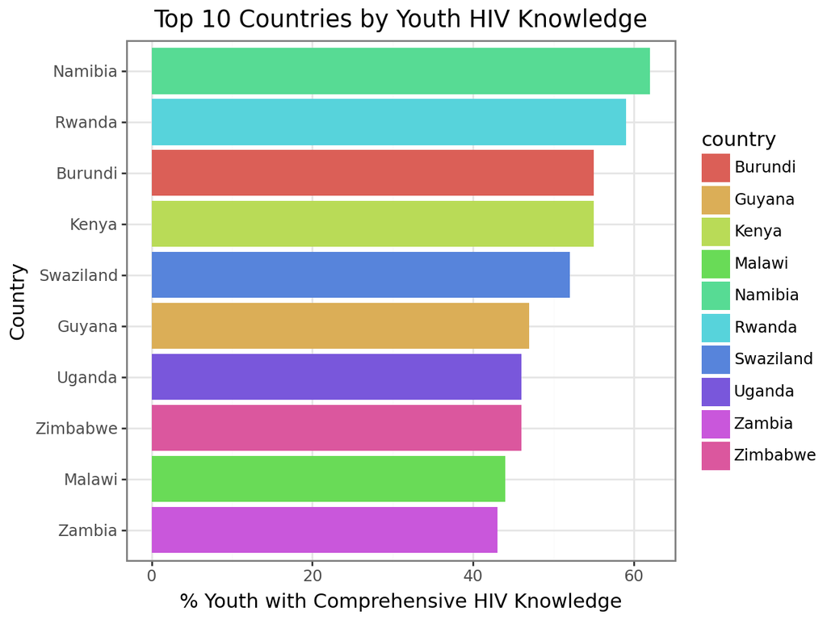

```python
top10_hiv = hiv_latest.sort("latest_obs_value", descending=True).head(10)

(ggplot(top10_hiv.to_pandas())
 + aes(x='reorder(country, latest_obs_value)', y='latest_obs_value', fill='country')
 + geom_col()
 + coord_flip()
 + labs(title="Top 10 Countries by Youth HIV Knowledge",
        x="Country",
        y="% Youth with Comprehensive HIV Knowledge")
 + theme_bw()
)
```

# HIV knowledge over time

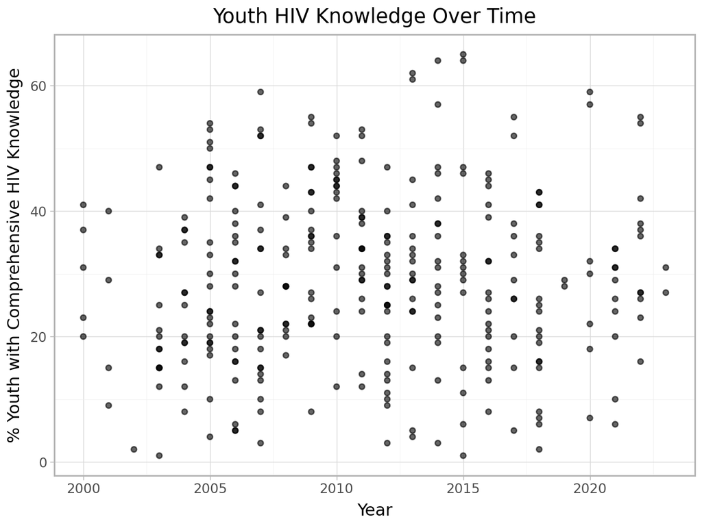

```python
(ggplot(data_hiv.to_pandas())
 + aes(x='time_period', y='obs_value')
 + geom_point(alpha=0.6)
 + labs(title="Youth HIV Knowledge Over Time",
        x="Year",
        y="% Youth with Comprehensive HIV Knowledge")
 + theme_light()
)
```